# AA_QUICK

## Quicksort

Sesuai dengan namanya, Quicksort adalah salah satu algoritma pengurutan tercepat.

QuickSort adalah algoritma pengurutan yang menggunakan pendekatan Divide and Conquer dengan memilih sebuah elemen sebagai pivot, lalu membagi array di sekitar pivot tersebut dengan menempatkan pivot pada posisi yang benar di dalam array yang sudah terurut.

1. Choose a Pivot: Pilih sebuah elemen dari array sebagai pivot. Pemilihan pivot dapat bervariasi, misalnya elemen pertama, elemen terakhir, elemen acak (random element), atau elemen median (median).
2. Partition the Array: Susun kembali array di sekitar pivot. Setelah proses partition selesai, semua elemen yang lebih kecil dari pivot akan berada di sebelah kiri, dan semua elemen yang lebih besar akan berada di sebelah kanan.
3. Recursively Call: Terapkan proses yang sama secara recursive pada dua sub-array hasil partition.
4. Base Case: Proses recursion berhenti ketika hanya tersisa satu elemen pada sub-array, karena satu elemen sudah dianggap terurut.

[figure not shown]

Algoritma Quicksort mengambil sebuah array nilai, memilih salah satu nilai sebagai elemen pivot, lalu memindahkan nilai-nilai lainnya sehingga nilai yang lebih kecil berada di sebelah kiri elemen pivot, dan nilai yang lebih besar berada di sebelah kanan pivot.

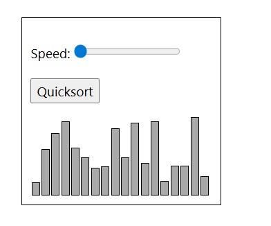

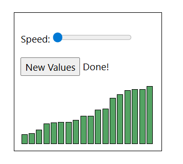

Pada tutorial ini, elemen terakhir dari array dipilih sebagai elemen pivot, tetapi sebenarnya kita juga bisa memilih elemen pertama atau elemen mana pun di dalam array sebagai pivot.

Kemudian, algoritma Quicksort melakukan operasi yang sama secara recursive pada sub-array di sebelah kiri dan kanan elemen pivot. Proses ini terus berlanjut sampai array menjadi terurut.

Recursion adalah ketika sebuah fungsi memanggil dirinya sendiri.

Setelah algoritma Quicksort menempatkan elemen pivot di antara sub-array dengan nilai lebih kecil di sebelah kiri dan sub-array dengan nilai lebih besar di sebelah kanan, algoritma akan memanggil dirinya sendiri dua kali. Dengan begitu, Quicksort dijalankan kembali untuk sub-array di sebelah kiri dan sub-array di sebelah kanan. Algoritma Quicksort terus memanggil dirinya sendiri sampai ukuran sub-array terlalu kecil untuk diurutkan.

Algoritma ini dapat dijelaskan seperti berikut.

Cara Kerja:

1. Pilih sebuah nilai di dalam array sebagai elemen pivot.
2. Atur sisa array sehingga nilai yang lebih kecil dari pivot berada di sebelah kiri, dan nilai yang lebih besar berada di sebelah kanan.
3. Tukar elemen pivot dengan elemen pertama dari kelompok nilai yang lebih besar sehingga elemen pivot berada di antara nilai yang lebih kecil dan nilai yang lebih besar.
4. Lakukan operasi yang sama secara recursive pada sub-array di sebelah kiri dan kanan elemen pivot.
5. Lanjutkan membaca untuk memahami sepenuhnya algoritma Quicksort dan cara mengimplementasikannya sendiri.

#### Choice of Pivot

Ada banyak cara berbeda untuk memilih pivot.

- Selalu memilih elemen pertama (atau terakhir) sebagai pivot. Implementasi di bawah memilih elemen terakhir sebagai pivot. Masalah dari pendekatan ini adalah dapat menghasilkan worst case ketika array sudah terurut.
- Memilih elemen acak sebagai pivot. Ini merupakan pendekatan yang lebih disukai karena tidak memiliki pola tertentu yang menyebabkan worst case terjadi.
- Memilih elemen median sebagai pivot. Ini adalah pendekatan ideal dari sisi time complexity karena median dapat ditemukan dalam waktu linear dan fungsi partition akan selalu membagi array input menjadi dua bagian yang seimbang. Namun, rata-rata waktu eksekusinya lebih besar karena proses pencarian median memiliki konstanta yang tinggi.

#### Partition Algorithm

Proses utama dalam QuickSort adalah fungsi partition(). Terdapat tiga algoritma partition yang umum digunakan. Semua algoritma tersebut memiliki time complexity O(n).

1. Naive Partition: Pada metode ini kita membuat salinan (copy) array. Pertama masukkan semua elemen yang lebih kecil, lalu semua elemen yang lebih besar. Setelah itu array sementara disalin kembali ke array asli. Metode ini membutuhkan ruang tambahan sebesar O(n).
2. Lomuto Partition: Metode ini digunakan pada artikel ini. Algoritma ini cukup sederhana, kita melacak index elemen yang lebih kecil lalu terus melakukan pertukaran (swapping). Metode ini digunakan karena lebih mudah dipahami.
3. Hoare's Partition: Ini adalah metode partition tercepat. Pada metode ini kita melakukan traversal array dari kedua sisi lalu menukar elemen besar di kiri dengan elemen kecil di kanan sampai array berhasil dipartisi. Silakan lihat pembahasan Hoare’s vs Lomuto untuk detail lebih lanjut.

#### Illustration of QuickSort Algorithm

Pada langkah sebelumnya, kita telah melihat bagaimana proses partition menyusun ulang array berdasarkan pivot yang dipilih. Selanjutnya, metode yang sama diterapkan secara recursive pada sub-array yang lebih kecil di sebelah kiri dan kanan pivot.

Setiap kali proses dilakukan, pivot baru dipilih dan array kembali dipartisi. Proses ini terus berlanjut sampai hanya tersisa satu elemen, yang selalu dianggap sudah terurut. Setelah setiap elemen berada pada posisi yang benar, seluruh array menjadi terurut.

Gambar di bawah mengilustrasikan bagaimana method recursive dipanggil untuk sub-array kecil di sebelah kiri dan kanan pivot.

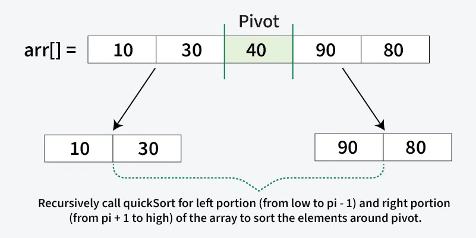

[figure not shown]

### Manual Run Through

Sebelum kita mengimplementasikan algoritma Quicksort menggunakan bahasa pemrograman, mari kita jalankan secara manual pada array pendek terlebih dahulu agar memahami konsep dasarnya.

Step 1

Kita mulai dengan array yang belum terurut.

```
[11, 9, 12, 7, 3]
```

Step 2

Kita memilih nilai terakhir yaitu 3 sebagai elemen pivot.

```
[11, 9, 12, 7, 3]
```

Step 3

Sisa nilai lain dalam array semuanya lebih besar dari 3, sehingga harus berada di sebelah kanan 3. Tukar 3 dengan 11.

```
[3, 9, 12, 7, 11]
```

Step 4

Nilai 3 sekarang sudah berada pada posisi yang benar. Kita perlu mengurutkan nilai di sebelah kanan 3. Kita memilih nilai terakhir yaitu 11 sebagai elemen pivot yang baru.

```
[3, 9, 12, 7, 11]
```

Step 5

Nilai 7 harus berada di sebelah kiri nilai pivot 11, dan 12 harus berada di sebelah kanan. Pindahkan 7 dan 12.

```
[3, 9, 7, 12, 11]
```

Step 6

Tukar 11 dengan 12 sehingga nilai yang lebih kecil yaitu 9 dan 7 berada di sebelah kiri 11, dan 12 berada di sebelah kanan.

```
[3, 9, 7, 11, 12]
```

Step 7

Nilai 11 dan 12 sekarang sudah berada pada posisi yang benar. Kita memilih 7 sebagai elemen pivot pada sub-array [9, 7], yang berada di sebelah kiri 11.

```
[3, 9, 7, 11, 12]
```

Step 8

Kita harus menukar 9 dengan 7.

```
[3, 7, 9, 11, 12]
```

Dan sekarang array sudah terurut.

Jalankan simulasi di bawah ini untuk melihat langkah-langkah di atas dalam bentuk animasi:

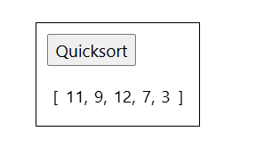

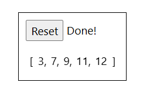

### Manual Run Through: Apa yang Terjadi?

Sebelum kita mengimplementasikan algoritma ini menggunakan bahasa pemrograman, kita perlu memahami lebih detail apa yang sebenarnya terjadi pada langkah-langkah di atas.

Kita sudah melihat bahwa nilai terakhir dari array dipilih sebagai elemen pivot, lalu sisa nilai lainnya diatur sehingga nilai yang lebih kecil dari nilai pivot berada di sebelah kiri, dan nilai yang lebih besar berada di sebelah kanan.

Setelah itu, elemen pivot ditukar dengan elemen pertama dari kelompok nilai yang lebih besar. Hal ini membagi array asli menjadi dua bagian, dengan elemen pivot berada di tengah antara nilai yang lebih kecil dan nilai yang lebih besar.

Sekarang kita perlu melakukan proses yang sama pada sub-array di sebelah kiri dan kanan dari elemen pivot sebelumnya. Jika sebuah sub-array memiliki panjang 0 atau 1, maka sub-array tersebut dianggap sudah selesai diurutkan.

Sebagai kesimpulan, algoritma Quicksort membuat sub-array menjadi semakin pendek sampai seluruh array berhasil diurutkan.

### Quicksort Implementation

Untuk membuat method quickSort yang membagi array menjadi sub-array yang semakin pendek, kita menggunakan recursion. Hal ini berarti method quickSort harus memanggil dirinya sendiri menggunakan sub-array baru di sebelah kiri dan kanan elemen pivot. Bacalah lebih lanjut mengenai recursion di halaman terkait.

Untuk mengimplementasikan algoritma Quicksort dalam bahasa pemrograman, kita membutuhkan:

1. Sebuah array yang berisi nilai untuk diurutkan.
2. Sebuah method quickSort yang memanggil dirinya sendiri (recursion) jika ukuran sub-array lebih besar dari 1.
3. Sebuah method partition yang menerima sub-array, memindahkan nilai-nilai di dalamnya, menukar elemen pivot ke posisi yang benar di dalam sub-array, lalu mengembalikan index tempat pembagian sub-array berikutnya dilakukan.

Kode hasil implementasinya terlihat seperti berikut.

Example

```python
def partition(array, low, high):
    pivot = array[high]
    i = low - 1

    for j in range(low, high):
        if array[j] <= pivot:
            i += 1
            array[i], array[j] = array[j], array[i]

    array[i+1], array[high] = array[high], array[i+1]
    return i+1

def quicksort(array, low=0, high=None):
    if high is None:
        high = len(array) - 1

    if low < high:
        pivot_index = partition(array, low, high)
        quicksort(array, low, pivot_index-1)
        quicksort(array, pivot_index+1, high)

my_array = [64, 34, 25, 12, 22, 11, 90, 5]
quicksort(my_array)
print("Sorted array:", my_array)
```

```
Sorted array: [5, 11, 12, 22, 25, 34, 64, 90]
```

#### Quicksort Time Complexity

Untuk penjelasan umum mengenai apa itu time complexity, kunjungi halaman terkait.

Untuk penjelasan yang lebih lengkap dan mendalam mengenai time complexity pada Quicksort, kunjungi halaman terkait.

Skenario terburuk (worst case scenario) untuk Quicksort adalah $O(n^2)$. Hal ini terjadi ketika elemen pivot selalu menjadi nilai paling besar atau paling kecil pada setiap sub-array, sehingga menyebabkan sangat banyak recursive calls. Pada implementasi kita sebelumnya, kondisi ini terjadi ketika array sudah dalam keadaan terurut.

Namun, secara rata-rata (average case), time complexity untuk Quicksort sebenarnya hanya $O(n$ log $n)$

Nilai tersebut jauh lebih baik dibandingkan algoritma sorting sebelumnya yang telah kita pelajari. Itulah alasan mengapa Quicksort sangat populer.

1. Best Case: Ω$(n$ log $n)$ Terjadi ketika elemen pivot membagi array menjadi dua bagian yang sama besar.
2. Average Case: θ$(n$ log $n)$ Rata-rata pivot membagi array menjadi dua bagian, tetapi tidak selalu sama besar.
3. Worst Case: $O(n^2)$ Terjadi ketika elemen terkecil atau terbesar selalu dipilih sebagai pivot, misalnya pada array yang sudah terurut.

#### Auxiliary Space

1. Worst-case scenario: $O(n)$ Hal ini disebabkan oleh partition yang tidak seimbang sehingga menghasilkan recursion tree yang miring (skewed recursion tree) dan membutuhkan call stack berukuran O(n).
2. Best-case scenario: $O($log $n)$ Hal ini terjadi karena partition yang seimbang menghasilkan recursion tree yang seimbang dan call stack berukuran O(log n).

### Advantages of Quick Sort

- Menggunakan pendekatan divide-and-conquer sehingga lebih mudah menyelesaikan masalah.
- Efisien untuk dataset berukuran besar.
- Memiliki overhead yang rendah karena hanya membutuhkan sedikit memori tambahan.
- Bersifat Cache Friendly karena bekerja langsung pada array yang sama tanpa menyalin data ke array tambahan.
- Menjadi algoritma umum tercepat untuk data berukuran besar ketika stability tidak diperlukan.
- Bersifat tail recursive sehingga seluruh optimasi tail call dapat diterapkan.

### Disadvantages of Quick Sort

- Memiliki worst-case time complexity sebesar $O(n^2)$ Kondisi ini terjadi ketika pivot dipilih dengan buruk.
- Bukan pilihan yang baik untuk dataset berukuran kecil.
- Bukan stable sort, yang berarti jika dua elemen memiliki key yang sama, maka urutan relatifnya mungkin tidak dipertahankan setelah sorting. Hal ini terjadi karena elemen ditukar berdasarkan posisi pivot tanpa mempertimbangkan posisi aslinya.

### Applications of Quick Sort

- Mengurutkan dataset besar secara efisien di memori.
- Digunakan pada library sorting seperti C++ std::sort dan Java Arrays.sort untuk tipe data primitive.
- Menyusun record dalam database agar pencarian lebih cepat.
- Digunakan sebagai tahap preprocessing pada algoritma yang memerlukan input terurut, seperti binary search dan two-pointer techniques.
- Menemukan elemen ke-k terkecil atau terbesar menggunakan Quickselect (variasi dari quicksort).
- Mengurutkan array objek berdasarkan banyak key menggunakan custom comparators.
- Digunakan dalam algoritma kompresi data seperti preprocessing pada Huffman Coding.
- Digunakan dalam bidang grafika dan computational geometry, misalnya algoritma convex hull.